# Лабораторийн ажил 12

## Classification

Ангилал гэдэг нь бусад атрибутын (урьдчилан таамаглах хувьсагч гэгддэг) утгууд дээр үндэслэн нэрлэсэн (nominal) утгатай атрибутыг (ангиллын шошго гэж нэрлэдэг) таамаглах ажил юм.

## Artificial neural network (ANN)

Мэдрэлийн сүлжээ нь оролт, гаралтын давхарга, түүнчлэн (ихэнх тохиолдолд) оролтыг гаралтын давхарга ашиглаж болох зүйл болгон хувиргадаг нэгжүүдээс бүрдэх далд давхаргаас бүрдэнэ. Мэдрэлийн сүлжээнүүд (мөн "перцептрон" гэж нэрлэдэг) 1940-өөд оноос хойш бий болсон ч сүүлийн хэдэн арван жилд л хиймэл оюун ухааны гол хэсэг болсон. Дараах жишээнд бид ANN ашиглан бороо орохыг урьдчилан таамаглана.

```python
import pandas as pd

df = pd.read_csv('weather.csv',header='infer')
df.head()
```

RAIN баганыг тоо руу хөрвүүлцгээе

```python
df['rain']=[1 if i==True else 0 for i in df['RAIN']]
df.head()
```

```python
df.columns
```

```python
df.info()
df.shape
```

```python
#Null утга агуулсан мөрүүдийг устгана
df.dropna(inplace=True)
df.shape
```

```python
from sklearn.model_selection import train_test_split
X=df[['PRCP', 'TMAX', 'TMIN']]
y=df[['rain']]

xtrain1,xtest,ytrain1,ytest=train_test_split(X,y,test_size=0.2, random_state=42)
xtrain,xval,ytrain,yval=train_test_split(xtrain1,ytrain1,test_size=0.3, random_state=42)
xtrain.head()
```

```python
print(xtrain.shape)
print(xval.shape)
print(xtest.shape)
```

Өгөгдөл нь янз бүрийн хэмжээс, масштаб (scale) бүхий атрибутуудыг агуулдаг. Өгөгдлийн атрибутуудын өөр өөр масштаб нь (scale) өгөгдлийн багцын загварчлалд сөргөөр нөлөөлдөг. Иймээс загварыг сургахын өмнө өгөгдлийг нэг ижил түвшний хуваарьт шилжүүлэх хэрэгтэй. Өөрөөр хэлбэл бид нормалчлал эсвэл стандартчилал (z score) хийх хэрэгтэй.

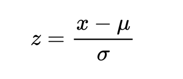

Python sklearn сан нь өгөгдлийн утгыг стандарт хэлбэрт оруулах StandardScaler() функцийг санал болгодог. Эхлээд StandardScaler() функцийн объектыг үүсгэх ба өгөгдлийг хувиргах, стандартчилахын тулд тухайн объектод fit_transform() функцийг ашигладаг.

```python
# Бид X утгыг хэвийн (normalization) болгох хэрэгтэй.
from sklearn.preprocessing import StandardScaler
scaler = StandardScaler()
xtrain = scaler.fit_transform(xtrain)
xtest = scaler.transform(xtest)
xval = scaler.transform(xval)

xtrain
```

## Ангиллын загварыг байгуулах

Keras Deep Learning сан нь мэдрэлийн сүлжээний загварыг хурдан бөгөөд хялбар боловсруулахад тусалдаг. Керас ашиглан загвар бүтээх хоёр арга бий. Түүний нэг нь Sequential API ашиглах юм.

**Sequential API ашиглах**

Загварыг байгуулахдаа давхаргуудыг дэс дараалан байрлуулах байдлаар хийдэг. Ихэнх тохиолдолд үүнийг ашиглан гүн сургалтын загварыг байгуулах нь маш хялбар байдаг. Дараах жишээг харцгаая.

Нийт 3 давхаргатай ANN загварыг үүсгэцгээе.

**Тэмдэглэл:** keras, tensorflow сангуудыг суулгах шаардлага гарч болно.

```python
import keras
from keras.layers import Dense
from keras.models import Sequential

ann  = Sequential()
ann.add(Dense(units= 32, activation = 'relu', input_dim=3))
ann.add(Dense(units= 16, activation = 'relu'))
ann.add(Dense(units= 1, activation = 'sigmoid'))
```

```python
ann.summary()
```

```python
from tensorflow.keras.utils import plot_model
plot_model(ann, show_dtype=True, show_layer_names=True, show_shapes=True)
```

## Загварыг байгуулах сүүлийн алхам (Compiling)

**Optimizer**

Алдагдлыг (loss) хамгийн бага байлгахын тулд сургалтын явцад загварын жингийн утгыг тохируулдаг алгоритм юм. Түгээмэл хэрэглэгддэг оновчлолын алгоритмуудад Adam, Stochastic Gradient Descent (SGD), RMSprop гэх мэт орно. Оновчлолын алгоримтын сонголт нь сургалтын үйл явцад ихээхэн нөлөөлдөг. Keras дараах оновчлолын алгоритмуудаар хангадаг.

- SGD − Stochastic gradient descent optimizer

```
keras.optimizers.SGD(learning_rate = 0.01, momentum = 0.0, nesterov = False)
```

- RMSprop − RMSProp optimizer.

```
keras.optimizers.RMSprop(learning_rate = 0.001, rho = 0.9)
```

- Adagrad − Adagrad optimizer.

```
keras.optimizers.Adagrad(learning_rate = 0.01)
```

- Adadelta − Adadelta optimizer.

```
keras.optimizers.Adadelta(learning_rate = 1.0, rho = 0.95)
```

- Adam − Adam optimizer.

```
keras.optimizers.Adam(
   learning_rate = 0.001, beta_1 = 0.9, beta_2 = 0.999, amsgrad = False
)
```

- Adamax − Adamax optimizer from Adam.

```
keras.optimizers.Adamax(learning_rate = 0.002, beta_1 = 0.9, beta_2 = 0.999)
```

- Nadam − Nesterov Adam optimizer.

```
keras.optimizers.Nadam(learning_rate = 0.002, beta_1 = 0.9, beta_2 = 0.999)
```

**Loss function**

Алдагдлын функц нь загварын таамаглал болон бодит зорилтот утгуудын хоорондын зөрүүг хэмждэг математик функц юм. Сургалтын зорилго нь энэ алдагдлыг багасгах явдал юм. Алдагдлын функцийн сонголт нь тухайн шийдэх гэж буй ажлын төрлөөс шалтгаална. Keras дараах алдагдлын функцүүдийг хангадаг.

- mean_squared_error
- mean_absolute_error
- mean_absolute_percentage_error
- mean_squared_logarithmic_error
- squared_hinge
- hinge
- categorical_hinge
- logcosh
- huber_loss
- categorical_crossentropy
- sparse_categorical_crossentropy
- binary_crossentropy
- kullback_leibler_divergence
- poisson
- cosine_proximity
- is_categorical_crossentropy

**Metrics**

Хэмжүүр нь сургалтын явцад болон дараа нь загварын гүйцэтгэлийг үнэлэхэд ашигладаг нэмэлт функцууд юм. Алдагдлын функц нь оновчлолын үйл явцыг удирдан чиглүүлэхэд ашиглагддаг бол хэмжүүрүүд нь тухайн загвар хэр сайн ажиллаж байгааг хүн унших боломжтой хэмжүүрээр хангадаг. Ангиллын даалгаврын нийтлэг хэмжүүрүүдэд accuracy, precision, recall, F1 score ордог.

```python
ann.compile(optimizer='adam', loss='mean_squared_error', metrics=['accuracy'])
```

## Загварыг сургах

Өгөгдөл дээрээ сургахын тулд **fit()** функцийг ашиглана.

```python
# fit функц нь загвар анхны утгуудаа авсны дараа сургалтын өгөгдөл дээр алгоритмыг сургадаг.

hist = ann.fit(xtrain,ytrain, batch_size=10, epochs=20,verbose= 1, validation_data=(xval,yval))
```

## Загварын гүйцэтгэлийг харах

Сургалтын болон баталгаажуулалтын өгөгдөл дээрх алдагдал (loss) болон нарийвчлалыг (accuracy) харцгаая.

```python
import matplotlib.pyplot as plt
plt.figure(figsize=(15,5))
# 1x2 grid, эхний subplot сонгох
plt.subplot(121)
plt.plot(hist.history['loss'],label='train_loss')
plt.plot(hist.history['val_loss'],label='val_loss')
plt.title("Loss")
plt.legend()
plt.suptitle("Performance evaluation")

# # 1x2 grid, хоёр дахь subplot сонгох
plt.subplot(122)
plt.plot(hist.history['accuracy'],label='train_accuracy')
plt.plot(hist.history['val_accuracy'],label='val_accuracy')
plt.title("Accuracy")
plt.legend()
plt.show()
```

```python
Y_pred = ann.predict(xtest)
Y_pred = [ 1 if y>=0.5 else 0 for y in Y_pred]
print(Y_pred)
```

```python
from sklearn.metrics import confusion_matrix
import seaborn as sns
import matplotlib.pyplot as plt

mat = confusion_matrix(ytest, Y_pred)
sns.heatmap(mat.T, square=True, annot=True, fmt='d', cbar=False, xticklabels=[0,1], yticklabels=[0,1])
plt.xlabel('true label')
plt.ylabel('predicted label');
```

```python
score = ann.evaluate(xtest, ytest, verbose=0)
print('Test loss:', score[0])
print('Test accuracy:', score[1])
```

## Дасгал

Чихрийн шижинтэй өвчтөнүүдийг ангилах загваруудыг үүсгэхийн тулд дараах өгөгдлийг ашиглана уу.

DATA: diabetes.csv

**Атрибутууд (Outcome нь зорилтот хувьсагч):**

- Pregnancies
- Glucose
- BloodPressure
- SkinThickness
- Insulin
- BMI (Body mass index)
- DiabetesPedigreeFunction
- Age

**Хийх даалгавар**

1. Өгөгдлийн эхний 5 бичлэгийг хэвлэ.
2. Бүх баганын хувьд статистик утгуудыг хэвлэж хар.
3. Дутуу утга (Missing value) байгаа эсэхийг шалга.
4. Хамгийн их хамааралтай 5 шинж чанаруудыг сонго (correlation matrix).
5. Атрибутуудыг нормчил.
6. Сонгосон хамгийн их хамааралтай атрибутууд дээр outlier байгаа эсэхийг шалгаж, байгаа бол устга.
   - Бидний ашиглаж буй өгөгдлийн хэмжээ бага тул зөвхөн аль нэг атрибутын хувьд outlier устгана уу.
7. Өгөгдлийн багцаас урьдчилан таамаглагч (X) болон зорилтот ангиллын (Y) шинж чанаруудыг гаргаж ав.
8. Өгөгдлийг сургалтын (training set) болон тестийн багц (test set) болгон хуваа.
9. ANN загварыг дараах тохируулгаар сурга.

**Оролтын давхарга, 2 далд давхарга, гаралтын давхарга:**

```
output dimension (units) = 24, сүүлийн давхаргын хувьд units = 1
activation function = 'relu', сүүлийн давхаргын хувьд activation = sigmoid
input_dim = 5
```

**Сургалтанд зориулж загварын тохиргоог:**

```
optimizer = 'adam'
loss = 'binary_crossentropy'
metrics = 'accuracy'
```